# GIVE ME SOME CREDIT

## MANUEL DEL PINO GUERRERO -- MASTER EN DATA SCIENCE - MACHINE LEARNING

ANALISIS EXPLORATORIO: GIVE ME SOME CREDIT

Our KPIs are:

LATE PAYMENT RATIO DELINQUENCY RATE (NO PAYMENT)

## Introducción

Para que los mercados funcionen, es necesario que, tanto las personas físicas como las empresas, tengan acceso al crédito, es decir, a financiarse. Por este motivo, las entidades financieras juegan un papel crucial en nuestra economía, ya que son las que deciden quién o quienes pueden obtener financiación y en qué términos van a adquirirla. Las entidades financieras, como no son adivinas, intentan desarrollar algoritmos de credit scoring, con el fin de poder determinar a base de estadística, matemáticas y una serie de técnicas, la probabilidad de default (impago) o no default de los créditos. Este caso, nos plantea el problema de llevar a cabo algoritmos para predecir de la mejor manera posible si un crédito va a ser impagado o no. Para ello, utilizamos una base de datos compuesta por, en este caso, 150000 créditos (muestra de training) indicándose características que se entienden como significativas y si en cada uno de los casos se ha impagado el crédito o no.  
Con estos 150000 se entrenarán una serie de logaritmos con el fin de determinar si en nuestra muestra de test (compuesta por 101503 casos), estos algoritmos han sido capaces de acertar el máximo posible de créditos con default y con no default.

## Objetivos

El objetivo de esta práctica es construir un modelo que los prestamistas puedan utilizar para tomar mejores decisiones financieras.

KPIs: accuracy ·Late Payment Ratio ·Delinquency Rate (no payment)

## Diccionario de datos

Se nos proporcionan dos datasets: 'cs-training.csv' y 'cs-test.csv'; utilizaremos ambos para la construcción del modelo, utilizando el primero para el modelo de training y el segundo para testear el mismo. Las variables de ambos son las siguientes:

SeriousDlqin2yrs: Persona que ha delinquido en los últimos 90 días

RevolvingUtilizationOfUnsecuredLines: Balance total de de tarjetas de crédito y lineas de crédito personales sin tener en cuenta ni la hipoteca ni préstamos por coche dividido entre la suma total de límites de crédito.

age: Edad de los solicitantes de crédito en años.

NumberOfTime30-59DaysPastDueNotWorse: Número de veces que el deudor ha estado 30-59 días sin pagar pero no peor en los últimos dos años.

DebtRatio: Pagos de deuda mensuales, pensión alimenticia, costes de vida dividido por los ingresos brutos mensuales.

MonthlyIncome: Ingresos mensuales.

NumberOfOpenCreditLinesAndLoans: Número de préstamos pendientes y lineas de crédito abiertas.

NumberOfTimes90DaysLate: Número de veces que el deudor ha estado 90 días o más sin pagar.

NumberRealEstateLoansOrLines: Número de hipotecas o préstamos inmobiliarios teniendo en cuenta lineas de crédito hipotecarias privadas.

NumberOfTime60-89DaysPastDueNotWorse: Número de veces que el deudor ha estado 60-89 días sin pagar pero no peor en los últimos dos años.

NumberOfDependents: Número de dependientes en tu familia excluyendose a sí mismo.

## Importación de librerías

```python
import pandas as pd
import numpy as np
import matplotlib.pyplot as plt
from matplotlib import pyplot
import seaborn as sns
import scipy
from sklearn import preprocessing,model_selection
import itertools
from sklearn import linear_model, tree, svm, naive_bayes
from sklearn.metrics import confusion_matrix
from sklearn import svm
from sklearn.preprocessing import LabelEncoder
from sklearn.linear_model import LogisticRegression
from sklearn.model_selection import train_test_split, cross_val_predict
from numpy import loadtxt
from sklearn.model_selection import train_test_split
from sklearn.metrics import accuracy_score
import xgboost as xgb
import xgboost as XGB
from xgboost import XGBClassifier
%matplotlib inline
```

```python
fileaddress = 'C:/Users/Knowhow/Desktop/CUNEF/MACHINE LEARNING/GIVEMESOMECREDIT'
train_data = pd.read_csv(fileaddress+'\\cs-training.csv')
test_data = pd.read_csv(fileaddress+'\\cs-test.csv')
print ("training dataset shape is {}".format(train_data.shape))
print ("testing dataset shape is {}".format(test_data.shape))
```

```
training dataset shape is (150000, 12)
testing dataset shape is (101503, 12)
```

Initial exploration Data dictionary SeriousDlqin2yrs: Personas que fueron delincuentes o peor en los 90 dias anteriores.

RevolvingUtilizationOfUnsecuredLines: Total balance on credit cards and personal lines of credit except real estate and no installment debt like car loans divided by the sum of credit limits

age Age of borrower in years

NumberOfTime30-59DaysPastDueNotWorse: Number of times borrower has been 30-59 days past due but no worse in the last 2 years.

DebtRatio: Monthly debt payments, alimony,living costs divided by monthy gross income

MonthlyIncome: Monthly income

NumberOfOpenCreditLinesAndLoans: Number of Open loans (installment like car loan or mortgage) and Lines of credit (e.g. credit cards)

NumberOfTimes90DaysLate: Number of times borrower has been 90 days or more past due.

NumberRealEstateLoansOrLines: Number of mortgage and real estate loans including home equity lines of credit

NumberOfTime60-89DaysPastDueNotWorse: Number of times borrower has been 60-89 days past due but no worse in the last 2 years.

NumberOfDependents: Number of dependents in family excluding themselves (spouse, children etc.)

```python
col_names = train_data.columns.values
col_names[0] = 'ID' ## Renombra primero la columna ID
train_data.columns = col_names ## Asigna una nueva columna "nombre" al training dataset
test_data.columns = col_names ## Asigna una nueva columna "nombre" al test dataset
```

```python
print ("Vamos a darle una ojeada al training dataset")
train_data.head(5)
```

```
Vamos a darle una ojeada al training dataset
```

|  | ID | SeriousDlqin2yrs | RevolvingUtilizationOfUnsecuredLines | age | NumberOfTime30-59DaysPastDueNotWorse | DebtRatio | MonthlyIncome | NumberOfOpenCreditLinesAndLoans | NumberOfTimes90DaysLate | NumberRealEstateLoansOrLines | NumberOfTime60-89DaysPastDueNotWorse | NumberOfDependents |
| --- | --- | --- | --- | --- | --- | --- | --- | --- | --- | --- | --- | --- |
| 0 | 1 | 1 | 0.766127 | 45 | 2 | 0.802982 | 9120.0 | 13 | 0 | 6 | 0 | 2.0 |
| 1 | 2 | 0 | 0.957151 | 40 | 0 | 0.121876 | 2600.0 | 4 | 0 | 0 | 0 | 1.0 |
| 2 | 3 | 0 | 0.658180 | 38 | 1 | 0.085113 | 3042.0 | 2 | 1 | 0 | 0 | 0.0 |
| 3 | 4 | 0 | 0.233810 | 30 | 0 | 0.036050 | 3300.0 | 5 | 0 | 0 | 0 | 0.0 |
| 4 | 5 | 0 | 0.907239 | 49 | 1 | 0.024926 | 63588.0 | 7 | 0 | 1 | 0 | 0.0 |

```python
train_data.tail(10)
```

|  | ID | SeriousDlqin2yrs | RevolvingUtilizationOfUnsecuredLines | age | NumberOfTime30-59DaysPastDueNotWorse | DebtRatio | MonthlyIncome | NumberOfOpenCreditLinesAndLoans | NumberOfTimes90DaysLate | NumberRealEstateLoansOrLines | NumberOfTime60-89DaysPastDueNotWorse | NumberOfDependents |
| --- | --- | --- | --- | --- | --- | --- | --- | --- | --- | --- | --- | --- |
| 149990 | 149991 | 0 | 0.055518 | 46 | 0 | 0.609779 | 4335.0 | 7 | 0 | 1 | 0 | 2.0 |
| 149991 | 149992 | 0 | 0.104112 | 59 | 0 | 0.477658 | 10316.0 | 10 | 0 | 2 | 0 | 0.0 |
| 149992 | 149993 | 0 | 0.871976 | 50 | 0 | 4132.000000 | NaN | 11 | 0 | 1 | 0 | 3.0 |
| 149993 | 149994 | 0 | 1.000000 | 22 | 0 | 0.000000 | 820.0 | 1 | 0 | 0 | 0 | 0.0 |
| 149994 | 149995 | 0 | 0.385742 | 50 | 0 | 0.404293 | 3400.0 | 7 | 0 | 0 | 0 | 0.0 |
| 149995 | 149996 | 0 | 0.040674 | 74 | 0 | 0.225131 | 2100.0 | 4 | 0 | 1 | 0 | 0.0 |
| 149996 | 149997 | 0 | 0.299745 | 44 | 0 | 0.716562 | 5584.0 | 4 | 0 | 1 | 0 | 2.0 |
| 149997 | 149998 | 0 | 0.246044 | 58 | 0 | 3870.000000 | NaN | 18 | 0 | 1 | 0 | 0.0 |
| 149998 | 149999 | 0 | 0.000000 | 30 | 0 | 0.000000 | 5716.0 | 4 | 0 | 0 | 0 | 0.0 |
| 149999 | 150000 | 0 | 0.850283 | 64 | 0 | 0.249908 | 8158.0 | 8 | 0 | 2 | 0 | 0.0 |

```python
print ("Vamos a darle una ojeada al testing dataset")
test_data.head(5)
```

```
Vamos a darle una ojeada al testing dataset
```

|  | ID | SeriousDlqin2yrs | RevolvingUtilizationOfUnsecuredLines | age | NumberOfTime30-59DaysPastDueNotWorse | DebtRatio | MonthlyIncome | NumberOfOpenCreditLinesAndLoans | NumberOfTimes90DaysLate | NumberRealEstateLoansOrLines | NumberOfTime60-89DaysPastDueNotWorse | NumberOfDependents |
| --- | --- | --- | --- | --- | --- | --- | --- | --- | --- | --- | --- | --- |
| 0 | 1 | 0 | 0.885519 | 43 | 0 | 0.177513 | 5700.0 | 4 | 0 | 0 | 0 | 0.0 |
| 1 | 2 | 0 | 0.463295 | 57 | 0 | 0.527237 | 9141.0 | 15 | 0 | 4 | 0 | 2.0 |
| 2 | 3 | 0 | 0.043275 | 59 | 0 | 0.687648 | 5083.0 | 12 | 0 | 1 | 0 | 2.0 |
| 3 | 4 | 0 | 0.280308 | 38 | 1 | 0.925961 | 3200.0 | 7 | 0 | 2 | 0 | 0.0 |
| 4 | 5 | 0 | 1.000000 | 27 | 0 | 0.019917 | 3865.0 | 4 | 0 | 0 | 0 | 1.0 |

```python
test_data.tail(10)
```

|  | ID | SeriousDlqin2yrs | RevolvingUtilizationOfUnsecuredLines | age | NumberOfTime30-59DaysPastDueNotWorse | DebtRatio | MonthlyIncome | NumberOfOpenCreditLinesAndLoans | NumberOfTimes90DaysLate | NumberRealEstateLoansOrLines | NumberOfTime60-89DaysPastDueNotWorse | NumberOfDependents |
| --- | --- | --- | --- | --- | --- | --- | --- | --- | --- | --- | --- | --- |
| 101493 | 101494 | 0 | 0.035549 | 58 | 0 | 0.290323 | 11128.0 | 7 | 0 | 2 | 0 | 2.0 |
| 101494 | 101495 | 0 | 0.218356 | 56 | 0 | 0.295803 | 1500.0 | 3 | 0 | 0 | 0 | 0.0 |
| 101495 | 101496 | 0 | 0.718874 | 35 | 1 | 0.308047 | 4125.0 | 8 | 0 | 0 | 1 | 2.0 |
| 101496 | 101497 | 0 | 0.021654 | 78 | 0 | 18.000000 | NaN | 8 | 0 | 0 | 0 | 0.0 |
| 101497 | 101498 | 0 | 0.045230 | 67 | 0 | 0.012198 | 5000.0 | 4 | 0 | 0 | 0 | 0.0 |
| 101498 | 101499 | 0 | 0.282653 | 24 | 0 | 0.068522 | 1400.0 | 5 | 0 | 0 | 0 | 0.0 |
| 101499 | 101500 | 0 | 0.922156 | 36 | 3 | 0.934217 | 7615.0 | 8 | 0 | 2 | 0 | 4.0 |
| 101500 | 101501 | 0 | 0.081596 | 70 | 0 | 836.000000 | NaN | 3 | 0 | 0 | 0 | NaN |
| 101501 | 101502 | 0 | 0.335457 | 56 | 0 | 3568.000000 | NaN | 8 | 0 | 2 | 1 | 3.0 |
| 101502 | 101503 | 0 | 0.441842 | 29 | 0 | 0.198918 | 5916.0 | 12 | 0 | 0 | 0 | 0.0 |

```python
print(train_data.dtypes)
```

```
ID                                        int64
SeriousDlqin2yrs                          int64
RevolvingUtilizationOfUnsecuredLines    float64
age                                       int64
NumberOfTime30-59DaysPastDueNotWorse      int64
DebtRatio                               float64
MonthlyIncome                           float64
NumberOfOpenCreditLinesAndLoans           int64
NumberOfTimes90DaysLate                   int64
NumberRealEstateLoansOrLines              int64
NumberOfTime60-89DaysPastDueNotWorse      int64
NumberOfDependents                      float64
dtype: object
```

```python
print(test_data.dtypes)
```

```
ID                                        int64
SeriousDlqin2yrs                          int64
RevolvingUtilizationOfUnsecuredLines    float64
age                                       int64
NumberOfTime30-59DaysPastDueNotWorse      int64
DebtRatio                               float64
MonthlyIncome                           float64
NumberOfOpenCreditLinesAndLoans           int64
NumberOfTimes90DaysLate                   int64
NumberRealEstateLoansOrLines              int64
NumberOfTime60-89DaysPastDueNotWorse      int64
NumberOfDependents                      float64
dtype: object
```

Vamos a observar la distribución para detectar posibles outliers. *"MonthlyIncome" y "NumberOfDependents" son eliminados en este punto ya que tienen "nan" values.

```python
#Vamos a dar una ojeada aleatoria al dataset para ver si existen valores perdidos (Nan) y poder así tratarlos.
train_data.sample(10)
```

|  | ID | SeriousDlqin2yrs | RevolvingUtilizationOfUnsecuredLines | age | NumberOfTime30-59DaysPastDueNotWorse | DebtRatio | MonthlyIncome | NumberOfOpenCreditLinesAndLoans | NumberOfTimes90DaysLate | NumberRealEstateLoansOrLines | NumberOfTime60-89DaysPastDueNotWorse | NumberOfDependents |
| --- | --- | --- | --- | --- | --- | --- | --- | --- | --- | --- | --- | --- |
| 85201 | 85202 | 0 | 0.012599 | 59 | 0 | 0.373406 | 4940.0 | 5 | 0 | 1 | 0 | 0.0 |
| 63745 | 63746 | 0 | 0.691542 | 48 | 1 | 0.042901 | 5500.0 | 3 | 0 | 0 | 0 | 1.0 |
| 46238 | 46239 | 0 | 0.016288 | 68 | 0 | 0.302669 | 16000.0 | 15 | 0 | 3 | 0 | 0.0 |
| 94397 | 94398 | 0 | 0.000000 | 34 | 0 | 0.198523 | 13000.0 | 9 | 0 | 2 | 0 | 1.0 |
| 21318 | 21319 | 0 | 0.259475 | 45 | 0 | 0.637871 | 4583.0 | 7 | 0 | 2 | 0 | 3.0 |
| 53885 | 53886 | 0 | 0.051820 | 29 | 0 | 0.084364 | 8000.0 | 8 | 0 | 0 | 0 | 1.0 |
| 10734 | 10735 | 0 | 0.197275 | 49 | 0 | 1.356700 | 5477.0 | 5 | 0 | 2 | 0 | 0.0 |
| 70426 | 70427 | 0 | 0.000000 | 59 | 0 | 0.415176 | 9000.0 | 10 | 0 | 1 | 0 | 0.0 |
| 100877 | 100878 | 0 | 0.929649 | 43 | 3 | 0.590750 | 3999.0 | 8 | 2 | 0 | 2 | 2.0 |
| 89079 | 89080 | 0 | 0.000000 | 55 | 0 | 0.048860 | 2455.0 | 7 | 0 | 0 | 0 | 1.0 |

Vamos a mirar la distribución de cada una de las características para ver si hay Outliers.

"MonthlyIncome" y "NumberOfDependents" van a ser eliminados ya que tienen Nan values.

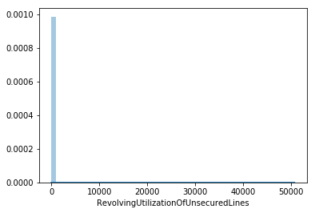

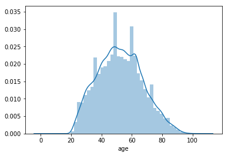

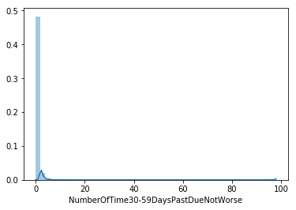

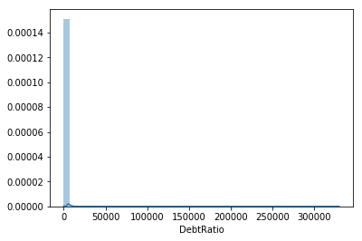

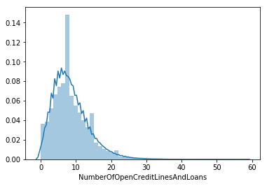

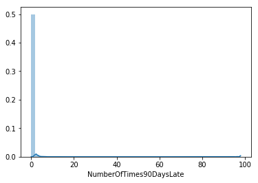

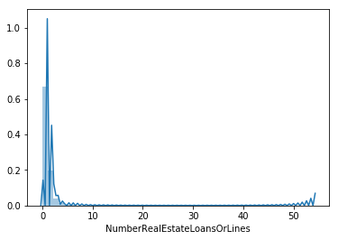

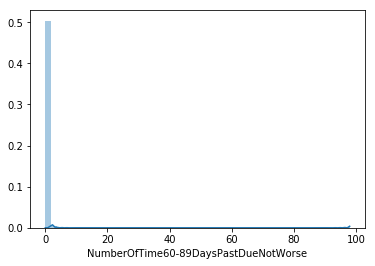

```python
# Como hemos dicho, eliminamos la variable ID, la variable objetivo (Dlqin2yrs)
#y las que tienen "nan" values nombradas antes.

feature_list=list(train_data.columns.values)
remove_list = ['ID','SeriousDlqin2yrs','MonthlyIncome','NumberOfDependents']
for each in remove_list:
    feature_list.remove(each)

for each in feature_list:
    sns.distplot(train_data[each])
    plt.show()
```

Como podemos ver en los gráficos anteriores, la distribución de algunas características está altamente sesgada. Para ver si podemos obtener un sesgo menor, vamos a realizar una transformación logarítmica.

```python
print(train_data.columns.values)
```

```
['ID' 'SeriousDlqin2yrs' 'RevolvingUtilizationOfUnsecuredLines' 'age'
 'NumberOfTime30-59DaysPastDueNotWorse' 'DebtRatio' 'MonthlyIncome'
 'NumberOfOpenCreditLinesAndLoans' 'NumberOfTimes90DaysLate'
 'NumberRealEstateLoansOrLines' 'NumberOfTime60-89DaysPastDueNotWorse'
 'NumberOfDependents']
```

```python
log_trans_list = train_data.columns.values[[2,4,5,8,9,10]]
log_trans_list
for each in log_trans_list:
    train_data[each] = np.log(1+train_data[each].values)
```

Distribución después de la transformación

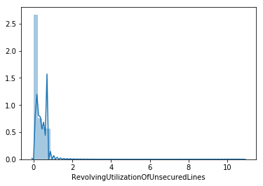

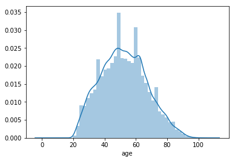

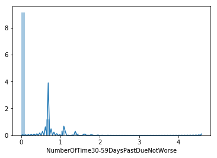

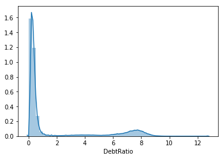

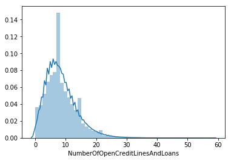

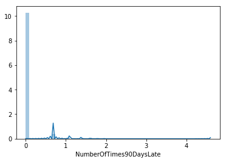

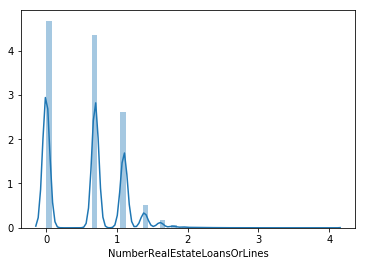

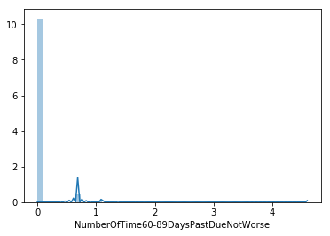

```python
for each in feature_list:
    sns.distplot(train_data[each])
    plt.show()
```

La distribución después de la transformación está mucho menos sesgada y por lo tanto es posible aplicarlo en un modelo de aprendizaje automático. Remove nan values in "MonthlyIncome" and "NumberOfDependents" to check their distribution

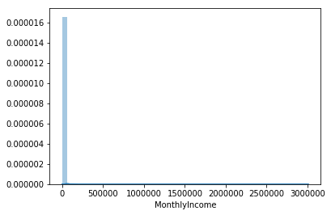

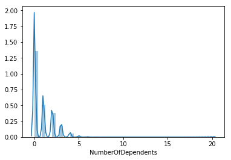

```python
partial_train_data = train_data[['MonthlyIncome','NumberOfDependents']]
#partial_train_data.dropna(how='any')
partial_train_data = partial_train_data.dropna(how='any')

sns.distplot(partial_train_data['MonthlyIncome'])
plt.show()
sns.distplot(partial_train_data['NumberOfDependents'])
plt.show()
```

La variable "monthlyIncome" está altamente sesgada. Vamos a realizar una transformación logarítmica en ambas para ver sus distribución de nuevo.

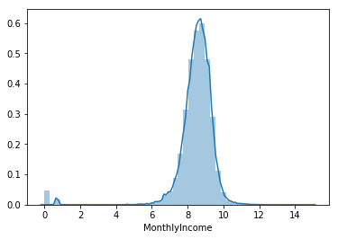

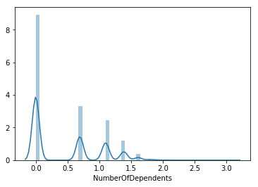

```python
partial_train_data['MonthlyIncome'] = np.log(1+partial_train_data['MonthlyIncome'].values)
partial_train_data['NumberOfDependents'] = np.log(1+partial_train_data['NumberOfDependents'].values)
sns.distplot(partial_train_data['MonthlyIncome'])
plt.show()
sns.distplot(partial_train_data['NumberOfDependents'])
plt.show()
```

Trás la transformación parece bastante menos sesgado que antes. Vamos a guardas dichas log transformations para ambos al mismo tiempo.

```python
train_data['MonthlyIncome'] = np.log(1+train_data['MonthlyIncome'].values)
train_data['NumberOfDependents'] = np.log(1+train_data['NumberOfDependents'].values)
```

Del mismo modo vamos a comprobar los missing values para el train_data y el test_data

```python
print (pd.isnull(train_data).sum(axis=0))
```

```
ID                                          0
SeriousDlqin2yrs                            0
RevolvingUtilizationOfUnsecuredLines        0
age                                         0
NumberOfTime30-59DaysPastDueNotWorse        0
DebtRatio                                   0
MonthlyIncome                           29731
NumberOfOpenCreditLinesAndLoans             0
NumberOfTimes90DaysLate                     0
NumberRealEstateLoansOrLines                0
NumberOfTime60-89DaysPastDueNotWorse        0
NumberOfDependents                       3924
dtype: int64
```

```python
print (pd.isnull(test_data).sum(axis=0))
```

```
ID                                          0
SeriousDlqin2yrs                            0
RevolvingUtilizationOfUnsecuredLines        0
age                                         0
NumberOfTime30-59DaysPastDueNotWorse        0
DebtRatio                                   0
MonthlyIncome                           20103
NumberOfOpenCreditLinesAndLoans             0
NumberOfTimes90DaysLate                     0
NumberRealEstateLoansOrLines                0
NumberOfTime60-89DaysPastDueNotWorse        0
NumberOfDependents                       2626
dtype: int64
```

Como podemos observar, las variables "Monthly Income" y "Number of Dependents" tienen múltiples nan values en sus datos. Vamos a crear nuevas variables para ver si las observaciones con nan values en estas 2 características son indicativas de un serio ratio de delicuencia (Target).

```python
train_data['MonthlyIncome_Null'] = pd.isnull(train_data['MonthlyIncome'])
grouped_df = train_data.groupby('MonthlyIncome_Null')
Dlqin = grouped_df['SeriousDlqin2yrs'].aggregate(np.mean).reset_index()
Dlqin
```

|  | MonthlyIncome_Null | SeriousDlqin2yrs |
| --- | --- | --- |
| 0 | False | 0.069486 |
| 1 | True | 0.056137 |

```python
train_data['NoD_Null'] = pd.isnull(train_data['NumberOfDependents'])
grouped_df = train_data.groupby('NoD_Null')
Dlqin = grouped_df['SeriousDlqin2yrs'].aggregate(np.mean).reset_index()
Dlqin
```

|  | NoD_Null | SeriousDlqin2yrs |
| --- | --- | --- |
| 0 | False | 0.067410 |
| 1 | True | 0.045617 |

Parece que las observaciones con Nan values en "Monthly Income y "Number of Dependents tienen un ratio más bajo de delincuencia que aquellas con valores normales (no Nan).

Agrupamos los datos por edad para ver así si existe algún patrón en el ratio de delincuencia con respecto a la variable "edad"

```
    age      mean  count
0     0  0.000000      1
1    21  0.071038    183
2    22  0.082949    434
3    23  0.109204    641
4    24  0.120098    816
5    25  0.126967    953
6    26  0.123219   1193
7    27  0.124066   1338
8    28  0.131410   1560
9    29  0.105170   1702
10   30  0.107899   1937
11   31  0.106477   2038
12   32  0.113659   2050
13   33  0.109870   2239
```

[output cut: 49 more lines]

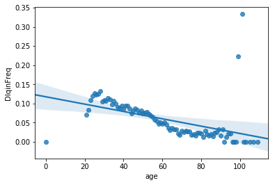

```python
grouped_df = train_data.groupby('age')
dlinq_age = grouped_df['SeriousDlqin2yrs'].aggregate([np.mean,'count']).reset_index()
print(dlinq_age)
dlinq_age.columns =['age','DlqinFreq','count']
sns.regplot(x='age',y='DlqinFreq',data=dlinq_age)
plt.show()
```

Por el gráfico de arriba podemos ver que:

*DlinFreq está negativamente associada con la edad en general edades 0,99 and 101 parecen outliers DlinFreq looks like a quardratic function of age. Put a higher order of age maybe helpful

**Ahora vamos a llevar a cabo un análisis exploratorio para la parte del test.**

```python
test_data.describe()
```

|  | ID | SeriousDlqin2yrs | RevolvingUtilizationOfUnsecuredLines | age | NumberOfTime30-59DaysPastDueNotWorse | DebtRatio | MonthlyIncome | NumberOfOpenCreditLinesAndLoans | NumberOfTimes90DaysLate | NumberRealEstateLoansOrLines | NumberOfTime60-89DaysPastDueNotWorse | NumberOfDependents |
| --- | --- | --- | --- | --- | --- | --- | --- | --- | --- | --- | --- | --- |
| count | 101503.000000 | 101503.0 | 101503.000000 | 101503.000000 | 101503.000000 | 101503.000000 | 8.140000e+04 | 101503.000000 | 101503.000000 | 101503.000000 | 101503.000000 | 98877.000000 |
| mean | 50752.000000 | 0.0 | 5.310000 | 52.405436 | 0.453770 | 344.475020 | 6.855036e+03 | 8.453514 | 0.296691 | 1.013074 | 0.270317 | 0.769046 |
| std | 29301.536524 | 0.0 | 196.156039 | 14.779756 | 4.538487 | 1632.595231 | 3.650860e+04 | 5.144100 | 4.515859 | 1.110253 | 4.503578 | 1.136778 |
| min | 1.000000 | 0.0 | 0.000000 | 21.000000 | 0.000000 | 0.000000 | 0.000000e+00 | 0.000000 | 0.000000 | 0.000000 | 0.000000 | 0.000000 |
| 25% | 25376.500000 | 0.0 | 0.030131 | 41.000000 | 0.000000 | 0.173423 | 3.408000e+03 | 5.000000 | 0.000000 | 0.000000 | 0.000000 | 0.000000 |
| 50% | 50752.000000 | 0.0 | 0.152586 | 52.000000 | 0.000000 | 0.364260 | 5.400000e+03 | 8.000000 | 0.000000 | 1.000000 | 0.000000 | 0.000000 |
| 75% | 76127.500000 | 0.0 | 0.564225 | 63.000000 | 0.000000 | 0.851619 | 8.200000e+03 | 11.000000 | 0.000000 | 2.000000 | 0.000000 | 1.000000 |
| max | 101503.000000 | 0.0 | 21821.000000 | 104.000000 | 98.000000 | 268326.000000 | 7.727000e+06 | 85.000000 | 98.000000 | 37.000000 | 98.000000 | 43.000000 |

Aquí podemos ver que la edad mínima es 21 y que la columna SeriousDlqin2yrs podemos observar casi lo mismo que en el resto de la lista, unas 101503 observaciones concretamente.

## ANÁLISIS EXPLORATIORIO

### Cómo de balanceado es nuestra variable objetivo?

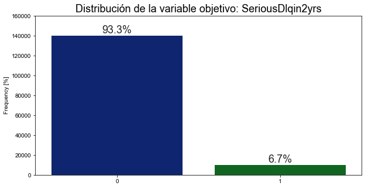

```python
ax = sns.countplot(x = train_data.SeriousDlqin2yrs ,palette="dark")
sns.set(font_scale=1.5)
ax.set_ylim(top = 150000)
plt.title('Distribución de la variable objetivo: SeriousDlqin2yrs')
ax.set_xlabel(' ')
ax.set_ylabel(' ')
fig = plt.gcf()
fig.set_size_inches(10,5)
ax.set_ylim(top=160000)
ax.set_ylabel('Frequency [%]')
ncount = len(train_data)
for p in ax.patches:
    x=p.get_bbox().get_points()[:,0]
    y=p.get_bbox().get_points()[1,1]
    ax.annotate('{:.1f}%'.format(100.*y/ncount), (x.mean(), y),
    ha='center', va='bottom')


plt.show()
```

Esta gráfica sin duda nos va a permitir observar como de desbalanceada nuestra variable es, viendo que el valor 0 tendrá un 93.3% de representación, mientras que el valor 1 toma el resto, 6.7%. Esto nos da a entender un enorme desbalanceo.

```python
tipo_0 = train_data.SeriousDlqin2yrs.value_counts()[0]
tipo_1 = train_data.SeriousDlqin2yrs.value_counts()[1]
print("Total number of tipo_0: {}".format(tipo_0))
print("Total number of tipo_1: {}".format(tipo_1))
print("Event rate: {} %".format(tipo_1/(tipo_0+tipo_1) *100))
```

```
Total number of tipo_0: 139974
Total number of tipo_1: 10026
Event rate: 6.683999999999999 %
```

### MATRIZ DE CORRELACIÓN

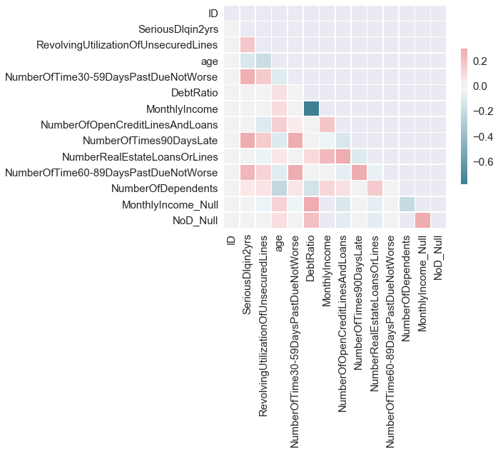

```python
corr = train_data.corr()

# Generamos una máscara
mask = np.zeros_like(corr, dtype=np.bool)
mask[np.triu_indices_from(mask)] = True

# Set up the matplotlib figure
f, ax = plt.subplots(figsize=(7, 7))

# Generate a custom diverging colormap
cmap = sns.diverging_palette(220, 10, as_cmap=True)

# Draw the heatmap with the mask and correct aspect ratio
sns.heatmap(corr, mask=mask, cmap=cmap, vmax=.3, center=0,
            square=True, linewidths=.5, cbar_kws={"shrink": .5})
```

Como podemos ver en las gráficas y su representación numérica, existe una fuerte relación entre la variable "NumberOfTimes90DaysLae" con "NumberOfTime3059DaysPastDueNotWorse y NumberOfTime6089DaysPastDueNotWorse". Mantener todas esas variables por tanto no va ser beneficioso en nuestro estudio ya que puede crear problemas de multi-colinealidad asi que debemos reorganizar el dataset eliminando dicho problema.

```python
#Establecemos una nueva columna que sea la suma de las 3, y así las combinamos y luego las convertimos en tipo factor

train_data["CombinedDefaulted"] = (train_data["NumberOfTimes90DaysLate"] + train_data["NumberOfTime60-89DaysPastDueNotWorse"])\
                                        + train_data["NumberOfTime30-59DaysPastDueNotWorse"]
train_data.loc[(train_data["CombinedDefaulted"] >= 1), "CombinedDefaulted"] = 1

train_data["CombinedCreditLoans"] = train_data["NumberOfOpenCreditLinesAndLoans"] + \
                                        train_data["NumberRealEstateLoansOrLines"]
train_data.loc[(train_data["CombinedCreditLoans"] <= 5), "CombinedCreditLoans"] = 0
train_data.loc[(train_data["CombinedCreditLoans"] > 5), "CombinedCreditLoans"] = 1
train_data.CombinedCreditLoans.value_counts()
```

```
1.0    111369
0.0     38631
Name: CombinedCreditLoans, dtype: int64
```

```python
#Convertimos dicha variable a categórica
train_data["WithDependents"] = train_data["NumberOfDependents"]
train_data.loc[(train_data["WithDependents"] >= 1), "WithDependents"] = 1
train_data.WithDependents.value_counts()
```

```
0.000000    86902
1.000000    32858
0.693147    26316
Name: WithDependents, dtype: int64
```

```python
train_data.isna().sum()
```

```
ID                                          0
SeriousDlqin2yrs                            0
RevolvingUtilizationOfUnsecuredLines        0
age                                         0
NumberOfTime30-59DaysPastDueNotWorse        0
DebtRatio                                   0
MonthlyIncome                           29731
NumberOfOpenCreditLinesAndLoans             0
NumberOfTimes90DaysLate                     0
NumberRealEstateLoansOrLines                0
NumberOfTime60-89DaysPastDueNotWorse        0
NumberOfDependents                       3924
MonthlyIncome_Null                          0
NoD_Null                                    0
CombinedDefaulted                           0
CombinedCreditLoans                         0
WithDependents                           3924
dtype: int64
```

```python
train_data["age_map"] = train_data["age"]
train_data.loc[(train_data["age"] >= 18) & (train_data["age"] < 60), "age_map"] = 1
train_data.loc[(train_data["age"] >= 60), "age_map"] = 0
#replacing those numbers to categorical features then get the dummy variables
train_data["age_map"] = train_data["age_map"].replace(0, "working")
train_data["age_map"] = train_data["age_map"].replace(1, "senior")
train_data = pd.concat([train_data, pd.get_dummies(train_data.age_map,prefix='is')], axis=1)
```

```python
train_data.info()
```

```
<class 'pandas.core.frame.DataFrame'>
RangeIndex: 150000 entries, 0 to 149999
Data columns (total 20 columns):
ID                                      150000 non-null int64
SeriousDlqin2yrs                        150000 non-null int64
RevolvingUtilizationOfUnsecuredLines    150000 non-null float64
age                                     150000 non-null int64
NumberOfTime30-59DaysPastDueNotWorse    150000 non-null float64
DebtRatio                               150000 non-null float64
MonthlyIncome                           120269 non-null float64
NumberOfOpenCreditLinesAndLoans         150000 non-null int64
NumberOfTimes90DaysLate                 150000 non-null float64
NumberRealEstateLoansOrLines            150000 non-null float64
NumberOfTime60-89DaysPastDueNotWorse    150000 non-null float64
NumberOfDependents                      146076 non-null float64
MonthlyIncome_Null                      150000 non-null bool
NoD_Null                                150000 non-null bool
CombinedDefaulted                       150000 non-null float64
CombinedCreditLoans                     150000 non-null float64
WithDependents                          146076 non-null float64
age_map                                 150000 non-null object
is_senior                               150000 non-null uint8
is_working                              150000 non-null uint8
dtypes: bool(2), float64(11), int64(4), object(1), uint8(2)
memory usage: 18.9+ MB
```

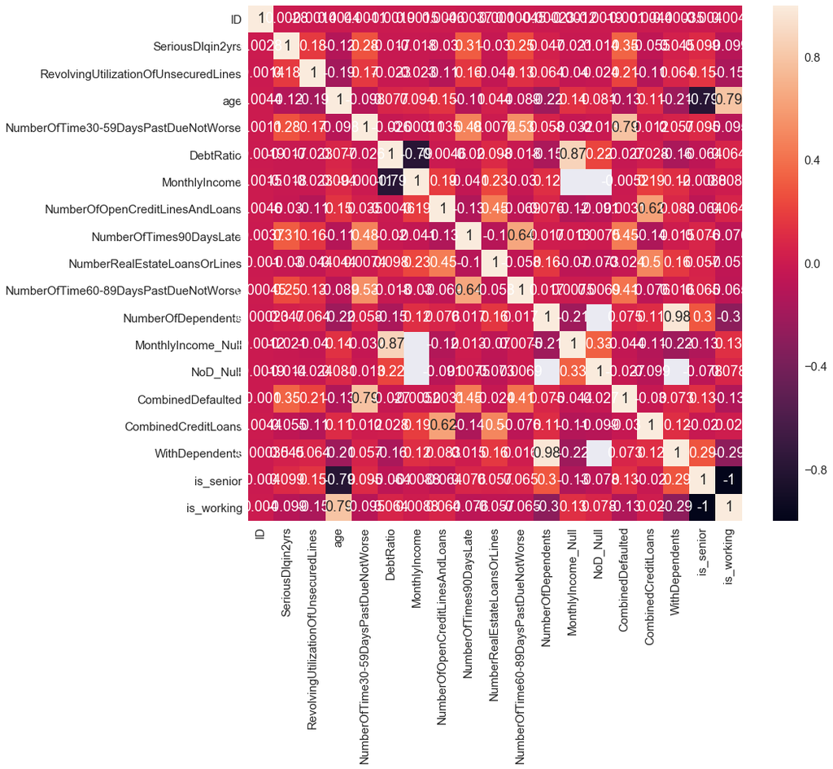

```python
corr = train_data.corr()
plt.figure(figsize=(14,12))
sns.heatmap(corr, annot=True, fmt=".2g")
```

```python
train_data.head(5)
```

|  | ID | SeriousDlqin2yrs | RevolvingUtilizationOfUnsecuredLines | age | NumberOfTime30-59DaysPastDueNotWorse | DebtRatio | MonthlyIncome | NumberOfOpenCreditLinesAndLoans | NumberOfTimes90DaysLate | NumberRealEstateLoansOrLines | NumberOfTime60-89DaysPastDueNotWorse | NumberOfDependents | MonthlyIncome_Null | NoD_Null | CombinedDefaulted | CombinedCreditLoans | WithDependents | age_map | is_senior | is_working |
| --- | --- | --- | --- | --- | --- | --- | --- | --- | --- | --- | --- | --- | --- | --- | --- | --- | --- | --- | --- | --- |
| 0 | 1 | 1 | 0.568789 | 45 | 1.098612 | 0.589442 | 9.118335 | 13 | 0.000000 | 1.945910 | 0.0 | 1.098612 | False | False | 1.000000 | 1.0 | 1.000000 | senior | 1 | 0 |
| 1 | 2 | 0 | 0.671490 | 40 | 0.000000 | 0.115002 | 7.863651 | 4 | 0.000000 | 0.000000 | 0.0 | 0.693147 | False | False | 0.000000 | 0.0 | 0.693147 | senior | 1 | 0 |
| 2 | 3 | 0 | 0.505721 | 38 | 0.693147 | 0.081684 | 8.020599 | 2 | 0.693147 | 0.000000 | 0.0 | 0.000000 | False | False | 1.000000 | 0.0 | 0.000000 | senior | 1 | 0 |
| 3 | 4 | 0 | 0.210107 | 30 | 0.000000 | 0.035415 | 8.101981 | 5 | 0.000000 | 0.000000 | 0.0 | 0.000000 | False | False | 0.000000 | 0.0 | 0.000000 | senior | 1 | 0 |
| 4 | 5 | 0 | 0.645657 | 49 | 0.693147 | 0.024620 | 11.060196 | 7 | 0.000000 | 0.693147 | 0.0 | 0.000000 | False | False | 0.693147 | 1.0 | 0.000000 | senior | 1 | 0 |

### Tratamiento de Datos perdidos

```python
train_data.loc[train_data["age"] < 18] #Como podemos observar el único que hay con menos de 18 años es solo un dato
```

|  | ID | SeriousDlqin2yrs | RevolvingUtilizationOfUnsecuredLines | age | NumberOfTime30-59DaysPastDueNotWorse | DebtRatio | MonthlyIncome | NumberOfOpenCreditLinesAndLoans | NumberOfTimes90DaysLate | NumberRealEstateLoansOrLines | NumberOfTime60-89DaysPastDueNotWorse | NumberOfDependents | MonthlyIncome_Null | NoD_Null | CombinedDefaulted | CombinedCreditLoans | WithDependents | age_map | is_senior | is_working |
| --- | --- | --- | --- | --- | --- | --- | --- | --- | --- | --- | --- | --- | --- | --- | --- | --- | --- | --- | --- | --- |
| 65695 | 65696 | 0 | 0.693147 | 0 | 0.693147 | 0.362507 | 8.699681 | 6 | 0.0 | 1.098612 | 0.0 | 1.098612 | False | False | 0.693147 | 1.0 | 1.0 | working | 0 | 1 |

```python
##Ahora vaamos a sustituir la variable que quedaba por la mediana
train_data.loc[train_data["age"] == 0, "age"] = train_data.age.median()
```

```python
#Definimos la variable de una persona trabajadora
age_working = train_data.loc[(train_data["age"] >= 18) & (train_data["age"] < 60)]
#Definimos la variable de una persona jubilada
age_senior = train_data.loc[(train_data["age"] >= 60)]

age_working_impute = age_working.MonthlyIncome.mean()
age_senior_impute = age_senior.MonthlyIncome.mean()
```

```python
train_data["MonthlyIncome"] = np.absolute(train_data["MonthlyIncome"])
train_data["MonthlyIncome"] = train_data["MonthlyIncome"].fillna(99999)
train_data["MonthlyIncome"] = train_data["MonthlyIncome"].astype('int64')
train_data.loc[((train_data["age"] >= 18) & (train_data["age"] < 60)) & (train_data["MonthlyIncome"] == 99999),\
               "MonthlyIncome"] = age_working_impute
train_data.loc[(train_data["age"] >= 60) & (train_data["MonthlyIncome"] == 99999), "MonthlyIncome"] = age_senior_impute
```

```python
train_data.isna().sum()
```

```
ID                                         0
SeriousDlqin2yrs                           0
RevolvingUtilizationOfUnsecuredLines       0
age                                        0
NumberOfTime30-59DaysPastDueNotWorse       0
DebtRatio                                  0
MonthlyIncome                              0
NumberOfOpenCreditLinesAndLoans            0
NumberOfTimes90DaysLate                    0
NumberRealEstateLoansOrLines               0
NumberOfTime60-89DaysPastDueNotWorse       0
NumberOfDependents                      3924
MonthlyIncome_Null                         0
NoD_Null                                   0
CombinedDefaulted                          0
CombinedCreditLoans                        0
WithDependents                          3924
age_map                                    0
is_senior                                  0
is_working                                 0
dtype: int64
```

```python
#Comprobamos que no existen para ese beneficio mensual.
train_data.loc[train_data["MonthlyIncome"] == 99999]
```

|  | ID | SeriousDlqin2yrs | RevolvingUtilizationOfUnsecuredLines | age | NumberOfTime30-59DaysPastDueNotWorse | DebtRatio | MonthlyIncome | NumberOfOpenCreditLinesAndLoans | NumberOfTimes90DaysLate | NumberRealEstateLoansOrLines | NumberOfTime60-89DaysPastDueNotWorse | NumberOfDependents | MonthlyIncome_Null | NoD_Null | CombinedDefaulted | CombinedCreditLoans | WithDependents | age_map | is_senior | is_working |
| --- | --- | --- | --- | --- | --- | --- | --- | --- | --- | --- | --- | --- | --- | --- | --- | --- | --- | --- | --- | --- |

```python
train_data["MonthlyDebtPayments"] = train_data["DebtRatio"] * train_data["MonthlyIncome"]
train_data["MonthlyDebtPayments"] = np.absolute(train_data["MonthlyDebtPayments"])
train_data["MonthlyDebtPayments"] = train_data["MonthlyDebtPayments"].astype('int64')
train_data["age"] = train_data["age"].astype('int64')
train_data["MonthlyIncome"] = train_data["MonthlyIncome"].astype('int64')
```

```python
train_data.isna().sum()
```

```
ID                                         0
SeriousDlqin2yrs                           0
RevolvingUtilizationOfUnsecuredLines       0
age                                        0
NumberOfTime30-59DaysPastDueNotWorse       0
DebtRatio                                  0
MonthlyIncome                              0
NumberOfOpenCreditLinesAndLoans            0
NumberOfTimes90DaysLate                    0
NumberRealEstateLoansOrLines               0
NumberOfTime60-89DaysPastDueNotWorse       0
NumberOfDependents                      3924
MonthlyIncome_Null                         0
NoD_Null                                   0
CombinedDefaulted                          0
CombinedCreditLoans                        0
WithDependents                          3924
age_map                                    0
is_senior                                  0
is_working                                 0
MonthlyDebtPayments                        0
dtype: int64
```

```python
train_data.drop(["NumberOfOpenCreditLinesAndLoans",\
                 "NumberOfTimes90DaysLate","NumberRealEstateLoansOrLines","NumberOfTime60-89DaysPastDueNotWorse",\
                 "WithDependents","age_map","is_senior","is_working", "MonthlyDebtPayments"], axis=1, inplace=True)
train_data.columns
```

```
Index(['ID', 'SeriousDlqin2yrs', 'RevolvingUtilizationOfUnsecuredLines', 'age',
       'NumberOfTime30-59DaysPastDueNotWorse', 'DebtRatio', 'MonthlyIncome',
       'NumberOfDependents', 'MonthlyIncome_Null', 'NoD_Null',
       'CombinedDefaulted', 'CombinedCreditLoans'],
      dtype='object')
```

```python
def cleaned_dataset(dataset):
    dataset.loc[dataset["age"] <= 18, "age"] = dataset.age.median()

    age_working = dataset.loc[(dataset["age"] >= 18) & (dataset["age"] < 60)]
    age_senior = dataset.loc[(dataset["age"] >= 60)]

    age_working_impute = age_working.MonthlyIncome.mean()
    age_senior_impute = age_senior.MonthlyIncome.mean()

    dataset["MonthlyIncome"] = np.absolute(dataset["MonthlyIncome"])
    dataset["MonthlyIncome"] = dataset["MonthlyIncome"].fillna(99999)
    dataset["MonthlyIncome"] = dataset["MonthlyIncome"].astype('int64')

    dataset.loc[((dataset["age"] >= 18) & (dataset["age"] < 60)) & (dataset["MonthlyIncome"] == 99999),\
                   "MonthlyIncome"] = age_working_impute
    dataset.loc[(train_data["age"] >= 60) & (dataset["MonthlyIncome"] == 99999), "MonthlyIncome"] = age_senior_impute
    dataset["NumberOfDependents"] = np.absolute(dataset["NumberOfDependents"])
    dataset["NumberOfDependents"] = dataset["NumberOfDependents"].fillna(0)
    dataset["NumberOfDependents"] = dataset["NumberOfDependents"].astype('int64')

    dataset["CombinedDefaulted"] = (dataset["NumberOfTimes90DaysLate"] + dataset["NumberOfTime60-89DaysPastDueNotWorse"])\
                                            + dataset["NumberOfTime30-59DaysPastDueNotWorse"]

    dataset.loc[(dataset["CombinedDefaulted"] >= 1), "CombinedDefaulted"] = 1

    dataset["CombinedCreditLoans"] = dataset["NumberOfOpenCreditLinesAndLoans"] + \
                                            dataset["NumberRealEstateLoansOrLines"]
    dataset.loc[(dataset["CombinedCreditLoans"] <= 5), "CombinedCreditLoans"] = 0
    dataset.loc[(dataset["CombinedCreditLoans"] > 5), "CombinedCreditLoans"] = 1

    dataset.drop(["NumberOfOpenCreditLinesAndLoans",\
                 "NumberOfTimes90DaysLate","NumberRealEstateLoansOrLines","NumberOfTime60-89DaysPastDueNotWorse"], axis=1, inplace=True)
```

```python
#Esto solo de sebe ejecutar 1 vez para limpiarlo
cleaned_dataset(test_data)
```

```python
test_data.info()
```

```
<class 'pandas.core.frame.DataFrame'>
RangeIndex: 101503 entries, 0 to 101502
Data columns (total 10 columns):
ID                                      101503 non-null int64
SeriousDlqin2yrs                        101503 non-null int64
RevolvingUtilizationOfUnsecuredLines    101503 non-null float64
age                                     101503 non-null float64
NumberOfTime30-59DaysPastDueNotWorse    101503 non-null int64
DebtRatio                               101503 non-null float64
MonthlyIncome                           101503 non-null float64
NumberOfDependents                      101503 non-null int64
CombinedDefaulted                       101503 non-null int64
CombinedCreditLoans                     101503 non-null int64
dtypes: float64(4), int64(6)
memory usage: 7.7 MB
```

### Tratamiento de Outliers

Para definir si hay o no outliers, necesitamos estandarizar las variables. Por ejemplo haciendo la media = 0 y la desviación típica = 1. Nuestra variable por tanto no tendrá Outliers si tiene un balance entre 0 y 1.

```python
#Estandarizamos variables
from sklearn.preprocessing import StandardScaler

MonthlyIncome_scaled = StandardScaler().fit_transform(train_data['MonthlyIncome'][:,np.newaxis]);
low_range = MonthlyIncome_scaled[MonthlyIncome_scaled[:,0].argsort()][:10]
high_range= MonthlyIncome_scaled[MonthlyIncome_scaled[:,0].argsort()][-10:]
print('outer range (low) of the distribution:')
print(low_range)
print('\nouter range (high) of the distribution:')
print(high_range)
```

```
outer range (low) of the distribution:
[[-6.67389012]
 [-6.67389012]
 [-6.67389012]
 [-6.67389012]
 [-6.67389012]
 [-6.67389012]
 [-6.67389012]
 [-6.67389012]
 [-6.67389012]
 [-6.67389012]]

outer range (high) of the distribution:
[[4.25653887]
 [4.25653887]
 [4.25653887]
 [4.25653887]
 [4.25653887]
 [4.25653887]
 [4.25653887]
 [5.0973411 ]
 [5.0973411 ]
 [5.0973411 ]]
```

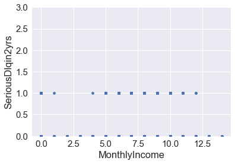

```python
#Análisis Bivariados monthlyincome/seriousdlqin2yrs
var = 'MonthlyIncome'
data = pd.concat([train_data['SeriousDlqin2yrs'], train_data[var]], axis=1)
data.plot.scatter(x=var, y='SeriousDlqin2yrs', ylim=(0,3))
```

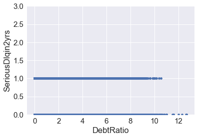

```python
#Análisis bivariado debtratio/seriousdlqin2yrs
var = 'DebtRatio'
data = pd.concat([train_data['SeriousDlqin2yrs'], train_data[var]], axis=1)
data.plot.scatter(x=var, y='SeriousDlqin2yrs', ylim=(0,3))
```

```python
train_data.DebtRatio.sort_values(ascending=False).head(10)
```

```
60152     12.705832
36600     12.696011
127047    12.634610
58900     12.303730
4854      12.036683
7513      11.616862
103041    11.579518
69845     11.526049
66785     11.033405
53682     11.020390
Name: DebtRatio, dtype: float64
```

```python
# Estandarizando variables

from sklearn.preprocessing import StandardScaler

DebtRatio_scaled = StandardScaler().fit_transform(train_data['DebtRatio'][:,np.newaxis]);
low_range = DebtRatio_scaled[DebtRatio_scaled[:,0].argsort()][:10]
high_range= DebtRatio_scaled[DebtRatio_scaled[:,0].argsort()][-10:]
print('outer range (low) of the distribution:')
print(low_range)
print('\nouter range (high) of the distribution:')
print(high_range)
```

```
outer range (low) of the distribution:
[[-0.58052594]
 [-0.58052594]
 [-0.58052594]
 [-0.58052594]
 [-0.58052594]
 [-0.58052594]
 [-0.58052594]
 [-0.58052594]
 [-0.58052594]
 [-0.58052594]]

outer range (high) of the distribution:
[[3.61415716]
 [3.61911098]
 [3.80662582]
 [3.82697774]
 [3.8411919 ]
 [4.00098812]
 [4.10263402]
 [4.22857643]
 [4.25194749]
 [4.25568589]]
```

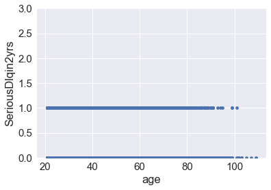

```python
#Análisis bivariado age/seriousdlqin2yrs
var = 'age'
data = pd.concat([train_data['SeriousDlqin2yrs'], train_data[var]], axis=1)
data.plot.scatter(x=var, y='SeriousDlqin2yrs', ylim=(0,3))
```

```python
age_scaled = StandardScaler().fit_transform(train_data['age'][:,np.newaxis])
low_range = age_scaled[age_scaled[:,0].argsort()][:10]
high_range= age_scaled[age_scaled[:,0].argsort()][-10:]
print('outer range (low) of the distribution:')
print(low_range)
print('\nouter range (high) of the distribution:')
print(high_range)
```

```
outer range (low) of the distribution:
[[-2.11868734]
 [-2.11868734]
 [-2.11868734]
 [-2.11868734]
 [-2.11868734]
 [-2.11868734]
 [-2.11868734]
 [-2.11868734]
 [-2.11868734]
 [-2.11868734]]

outer range (high) of the distribution:
[[3.36495669]
 [3.36495669]
 [3.36495669]
 [3.432656  ]
 [3.432656  ]
 [3.432656  ]
 [3.56805462]
 [3.70345324]
 [3.83885186]
 [3.83885186]]
```

```python
train_data.age.sort_values(ascending= False).head(15)
```

```
105790    109
138291    109
40007     107
56761     105
135025    103
57967     103
19884     103
25561     102
90937     102
96450     102
93813     101
7763      101
116129    101
24007      99
59392      99
Name: age, dtype: int64
```

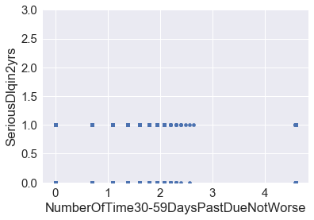

```python
#Análisis bivariado "NumberOfTime30-59DaysPastDueNotWorse/seriousdlqin2yrs"
var = 'NumberOfTime30-59DaysPastDueNotWorse'
data = pd.concat([train_data['SeriousDlqin2yrs'], train_data[var]], axis=1)
data.plot.scatter(x=var, y='SeriousDlqin2yrs', ylim=(0,3))
```

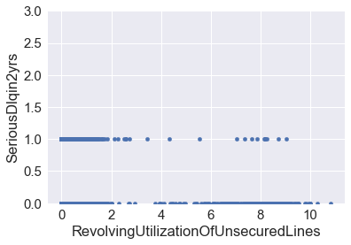

```python
#Análisis bivariado "RevolvingUtilizationOfUnsecuredLines/seriousdlqin2yrs"
var = 'RevolvingUtilizationOfUnsecuredLines'
data = pd.concat([train_data['SeriousDlqin2yrs'], train_data[var]], axis=1)
data.plot.scatter(x=var, y='SeriousDlqin2yrs', ylim=(0,3))
```

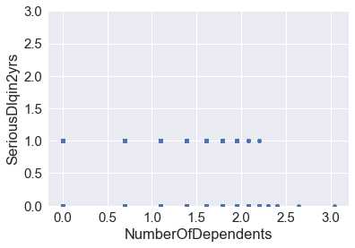

```python
#Análisis bivariado NumberOfDependents/seriousdlqin2yrs
var = 'NumberOfDependents'
data = pd.concat([train_data['SeriousDlqin2yrs'], train_data[var]], axis=1)
data.plot.scatter(x=var, y='SeriousDlqin2yrs', ylim=(0,3))
```

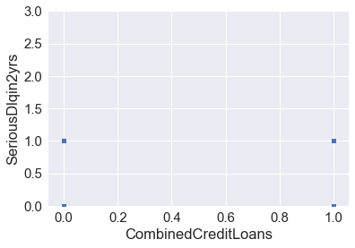

```python
#Análisis bivariado CombinedCreditLoans/seriousdlqin2yrs
var = 'CombinedCreditLoans'
data = pd.concat([train_data['SeriousDlqin2yrs'], train_data[var]], axis=1)
data.plot.scatter(x=var, y='SeriousDlqin2yrs', ylim=(0,3))
```

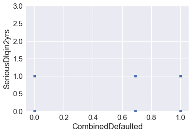

```python
#Análisis bivariado CombinedDefaulted/seriousdlqin2yrs
var = 'CombinedDefaulted'
data = pd.concat([train_data['SeriousDlqin2yrs'], train_data[var]], axis=1)
data.plot.scatter(x=var, y='SeriousDlqin2yrs', ylim=(0,3))
```

```python
train_data.NumberOfDependents.sort_values(ascending=False).head(3)
```

```
6299      3.044522
128034    2.639057
22698     2.397895
Name: NumberOfDependents, dtype: float64
```